# Introducción a la programación y análisis de datos en R

Día 4 · Bloque 1 — Introducción a la visualización de datos con ggplot2 y la gramática de gráficos

Filip Andras

CIMCYC — Universidad de Granada

30 octubre 2026

## Repaso del curso

| Día 1 · 9 oct | Día 2 · 16 oct | Día 3 · 23 oct | Día 4 · 30 oct |
| --- | --- | --- | --- |
| Intro a R y RStudio, primer script | Proyectos, pipe, tidyverse: `select()` y `filter()` | Reestructurar datos: `pivot_longer()`, `pivot_wider()`; descriptivos: `describe()` | Visualización de datos con `ggplot2` |
| R como calculadora, variables, vectores y `NA` | Transformar datos: `mutate()`, `arrange()`, `case_when()`, unir tablas | La fórmula `VD ~ VI`; correlación: `cor.test()`; comparar dos grupos: `t.test()` | Reportes reproducibles con Quarto |
| Data frames, paquetes e importar datos | Resumir por grupos: `group_by()` + `summarise()`; la Tabla 1 | ANOVA de una vía y ANOVA mixto: `aov_car()`, `emmeans()` | Ejercicio final: el informe del ensayo en Quarto; comentarios, preguntas, siguientes pasos |

## Mapa del día 4

Bloque 1  
9:00 – 10:30

Visualización de datos

La gramática de `ggplot2`

Un gráfico paso a paso

Ej. 1

Otros gráficos del ensayo

Bloque 2  
11:00 – 12:30

Quarto: reportes reproducibles

Crear un documento: YAML, chunks, Markdown

Ej. 2

Se presenta el Ej. 3 (final)

Cierre del curso

Bloque 3  
13:00 – 14:00 · 60’

Ej. 3 (final): el informe del ensayo

Comentarios, preguntas, siguientes pasos

## El paquete de este bloque: `ggplot2`

[figure not shown]

[`readr`](https://rstudio.github.io/cheatsheets/html/data-import.html)Importar archivos (CSV, TSV, etc.)

[`ggplot2`](https://rstudio.github.io/cheatsheets/html/data-visualization.html)Visualización de datos (gráficos)

[`forcats`](https://rstudio.github.io/cheatsheets/html/factors.html)Trabajar con factores (variables categóricas)

[`tidyr`](https://rstudio.github.io/cheatsheets/html/tidyr.html)Reestructurar datos (pivotar, separar, unir)

[`tibble`](https://tibble.tidyverse.org/)Data frames mejorados

[`dplyr`](https://rstudio.github.io/cheatsheets/html/data-transformation.html)Manipulación de datos (filtrar, seleccionar, transformar)

[`stringr`](https://rstudio.github.io/cheatsheets/html/strings.html)Manipulación de texto

[`purrr`](https://rstudio.github.io/cheatsheets/html/purrr.html)Programación funcional (iteración)

Haz clic en `ggplot2` para abrir su chuleta oficial (*cheatsheet*).

# Visualización de Datos

## R for Data Science

- [Cap. 1. Visualization. En *R for Data Science*. 2ed.](https://r4ds.hadley.nz/data-visualize.html)

## Visualización de Datos en R: Algunos recursos

[figure not shown]

- [Healy (2026). Data Visualization. A practical introduction](https://socviz.co/)

## Fundamentals of Data Visualization

[figure not shown]

- [Wilke (2019). *Fundamentals of Data Visualization*](https://clauswilke.com/dataviz/) — libro completo, gratuito en línea

## Visualización de Datos en R: para inspirarse

- [The R Graph Gallery](https://r-graph-gallery.com/)
- [The React Graph Gallery](https://www.react-graph-gallery.com/)
- [From Data to Viz](https://www.data-to-viz.com/#stackedarea)
- [Data Viz Inspiration](https://www.dataviz-inspiration.com/)
- [Top R Graph Examples: A curated collection](https://r-graph-gallery.com/best-r-chart-examples)

## Cambios en la Visualización de Datos en R [The R Graph Gallery](https://r-graph-gallery.com/)

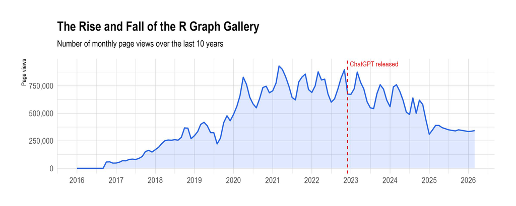

- AI puede hacer gráficos por ti
- Los gráficos cuentan historias
- Pensar críticamente qué y cómo presentar los datos y las historias

## Mira los datos para evitar errores

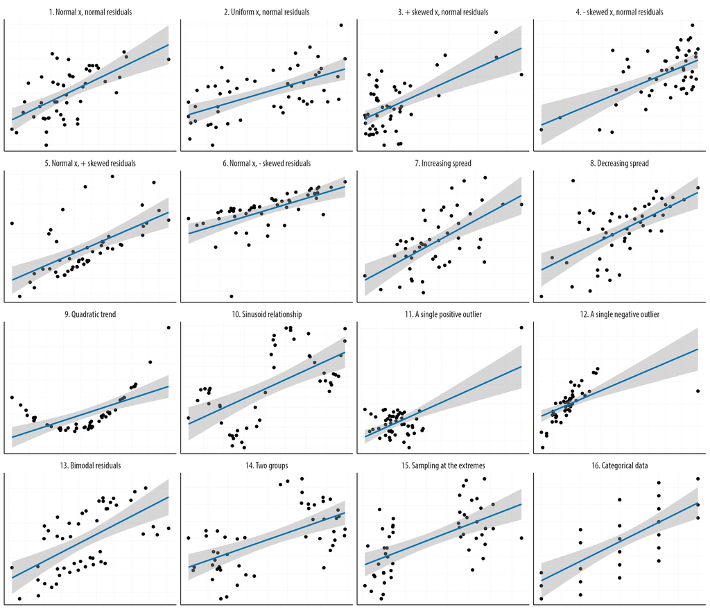

Healy (2026). Figure 1.5: What data patterns can lie behind a correlation? The correlation coefficient in all these plots is 0.6. Figure adapted from code by Jan Vanhove.

## Sigue explorando los datos

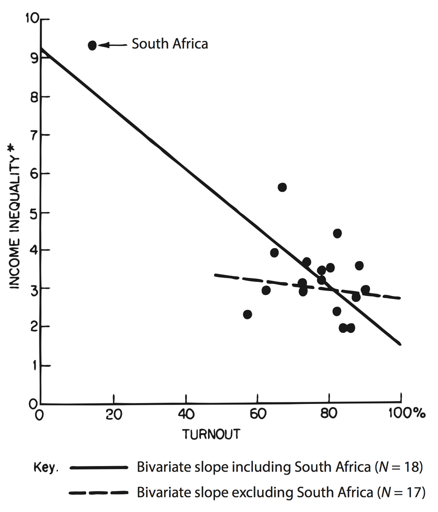

## Mira los datos para *ser más precisos/as*

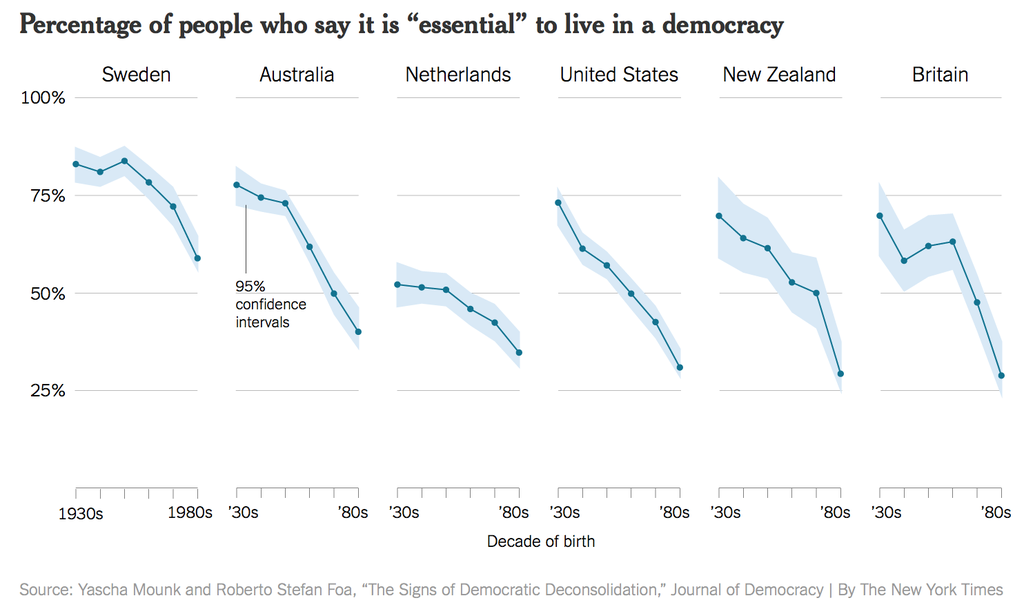

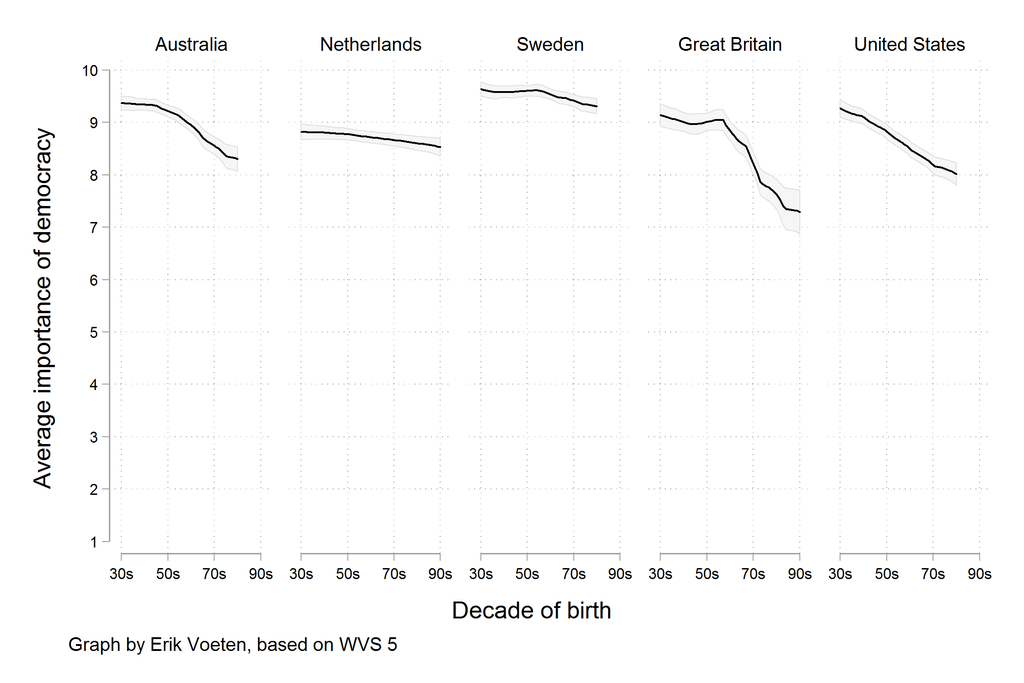

## ¿Qué hace a un gráfico “malo”?

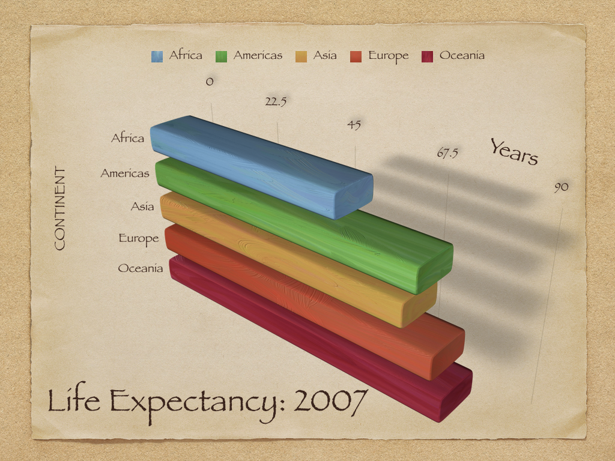

- Información innecesaria (“*junk info*”)
- Perspectivas que dificultan la comparación
- Datos engañosos o difíciles de interpretar

## Visualización de datos combina algo de ciencia y artesanía

> Graphical excellence is the well-designed presentation of interesting data—a matter of substance, of statistics, and of design … [It] consists of complex ideas communicated with clarity, precision, and efficiency. … [It] is that which gives to the viewer the greatest number of ideas in the shortest time with the least ink in the smallest space … [It] is nearly always multivariate … And graphical excellence requires telling the truth about the data. (Tufte 1983, 51).

[figure not shown]

## Tufte en `ggplot2`: el paquete `ggthemes`

La misma información con la mínima tinta: `theme_tufte()` quita fondo, rejilla y bordes; `geom_tufteboxplot()` reduce la caja a un punto (mediana) y dos líneas (cuartiles y rango).

**Código**

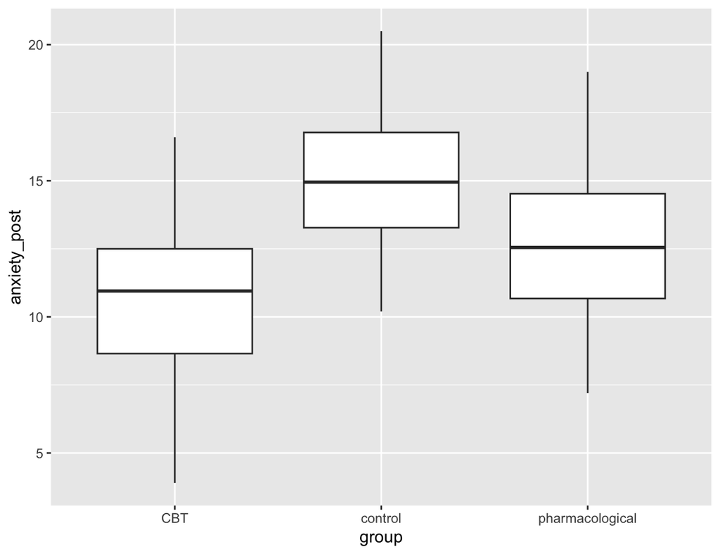

```r
# el boxplot de ggplot2 tal cual sale
ggplot(data = data_trial,
       mapping = aes(x = group, y = anxiety_post)) +
  geom_boxplot()
```

**Código**

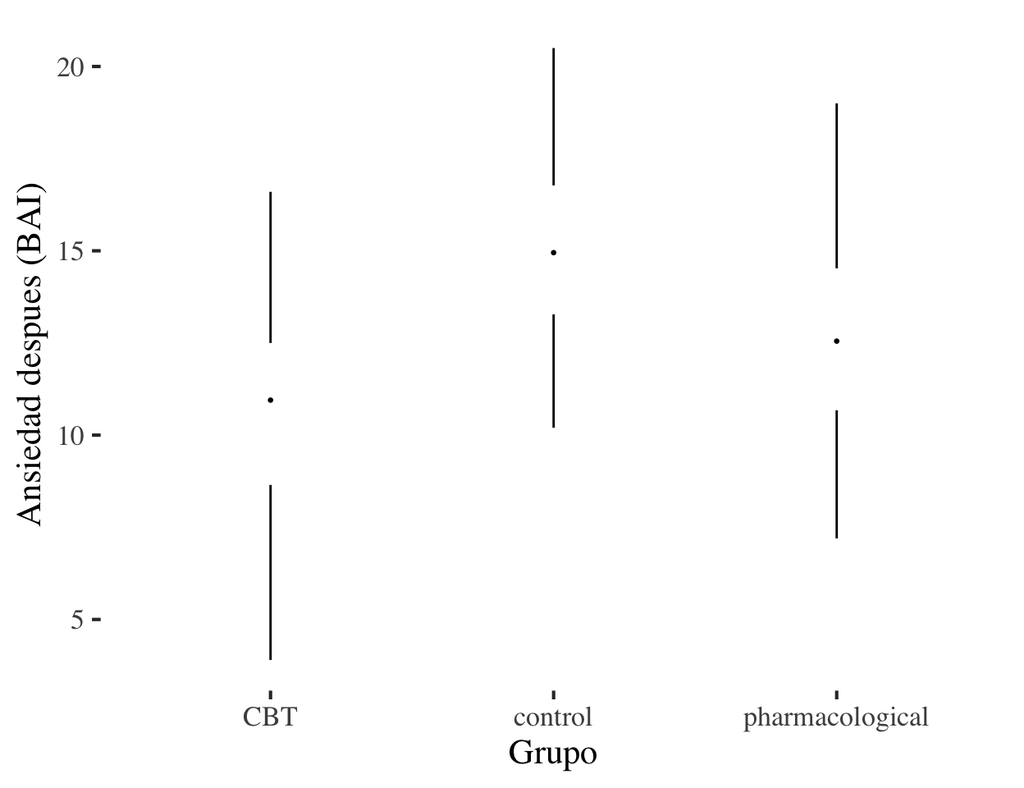

```r
# install.packages("ggthemes")
library(ggthemes)

ggplot(data = data_trial,
       mapping = aes(x = group, y = anxiety_post)) +
  geom_tufteboxplot() +
  labs(x = "Grupo", y = "Ansiedad despues (BAI)") +
  theme_tufte(base_size = 16)
```

## ¿Qué hace a un gráfico bueno?

Cada propiedad visual (posición, **color**, **forma**, tamaño) es un **canal**. Mismos datos del ensayo, mismos canales (color + forma):

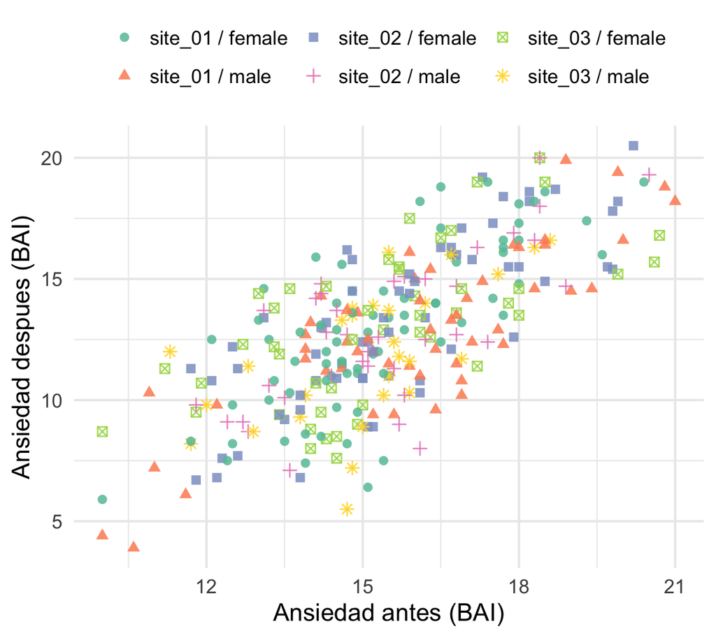

Color y forma = **centro × sexo**: no hay estructura, los canales solo añaden ruido

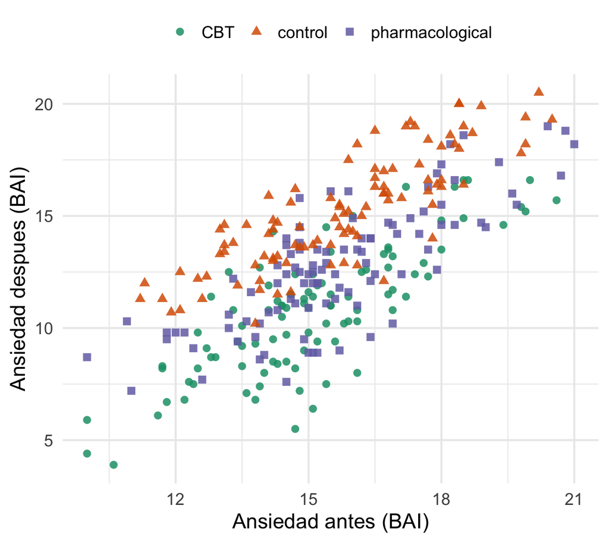

Color y forma = **grupo de tratamiento**: hay estructura y los canales la muestran

**Añade un canal solo si enseña algo**; si no, menos es más.

## Consideraciones para un buen gráfico: tipo de visualización

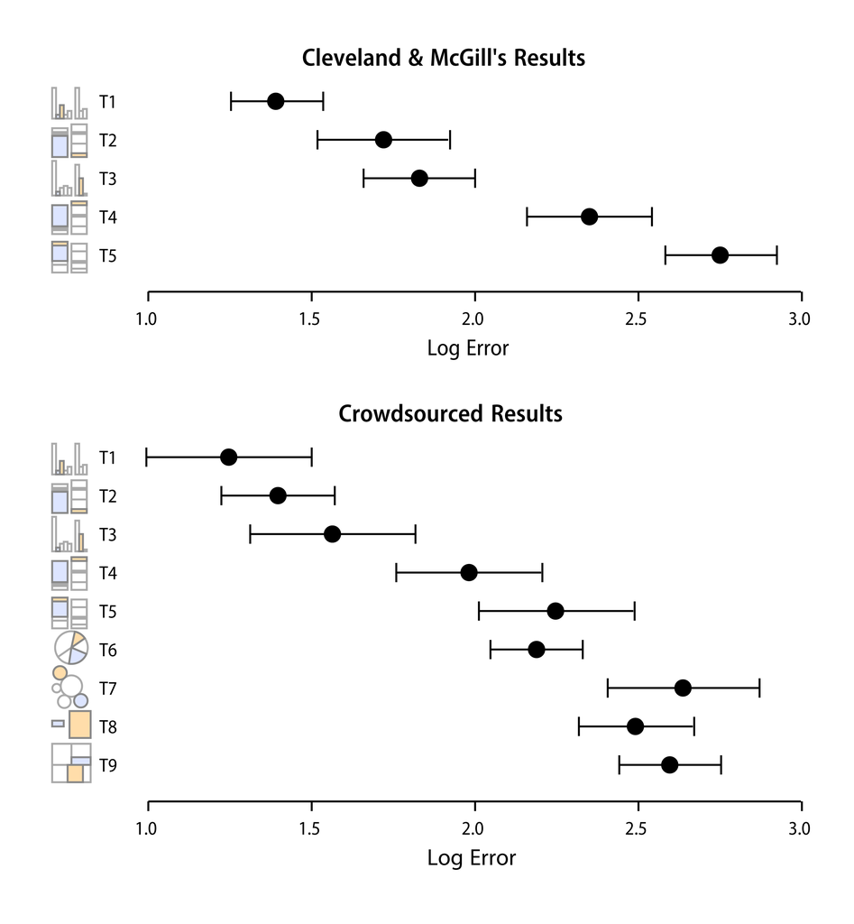

Figure 1.25: Cleveland and McGill’s original results (top) and Heer and Bostock’s replication with additions (bottom) for nine chart types.

## ¿Qué es mejor? Atención a las escalas

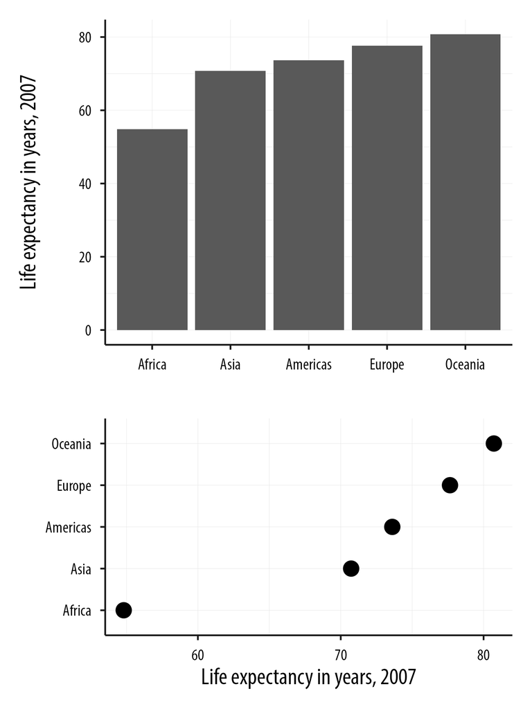

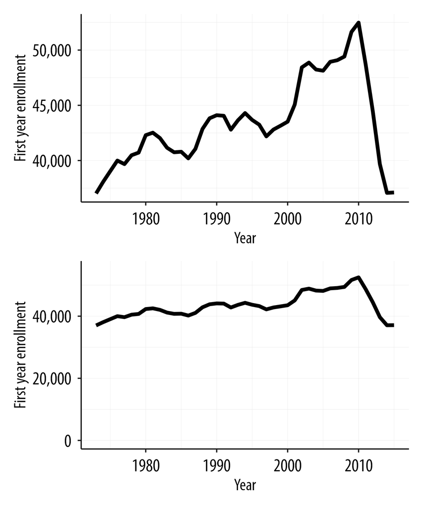

## ¿Por qué ggplot2?

- Parte del tidyverse — consistente, elegante, potente
- Basado en la **Gramática de Gráficos**: construir plots capa por capa
- Altamente personalizable: colores, temas, facetas, anotaciones
- Salida de **calidad de publicación**
- Muchas posibilidades

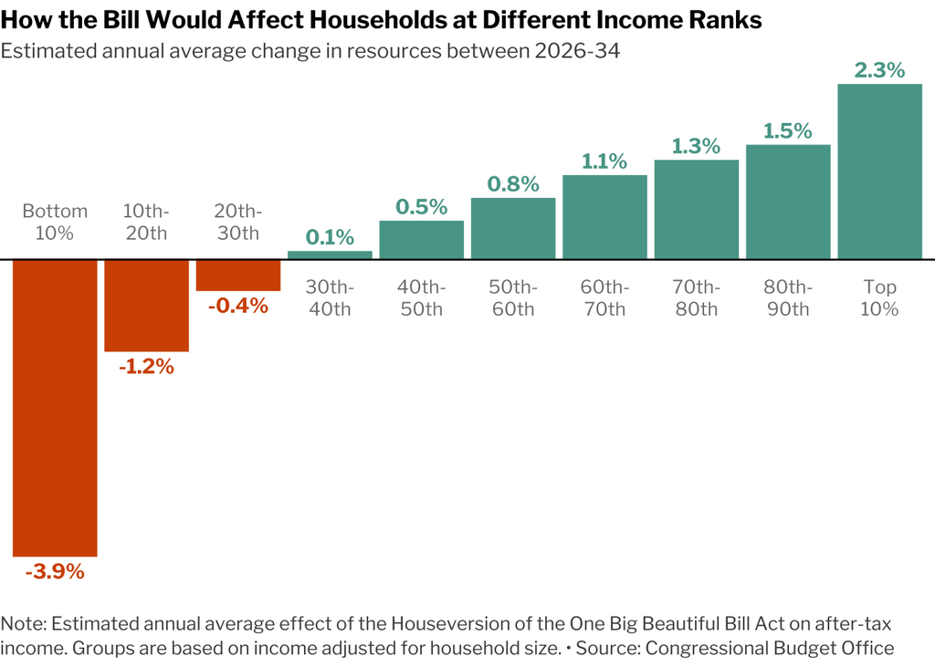

# La gramática de los gráficos en `ggplot2`

## Las capas de ggplot2 (*lo esencial*)

1. **Datos**: el dataset que quieres visualizar
2. **Estéticas (`aes`)**: qué variables van en x, y, color, tamaño, forma…
3. **Geometrías (`geom_*`)**: cómo dibujar los datos (puntos, barras, líneas…)
4. Las capas se **suman** con `+`, no con el pipe `|>`: ggplot2 es anterior al pipe y construye el gráfico capa a capa

```r
ggplot(data = mis_datos,
       mapping = aes(x = mi_variable_x,
                      y = mi_variable_y,
                      color = mi_variable_color)) +
  geom_*()
```

## Vamos a practicar: nuestro ensayo clínico

```r
# los datos que limpiamos el dia 2 y analizamos el dia 3
library(tidyverse)
library(here)

data_trial <- read_csv(here("data", "raw_data", "data_clinical_trial.csv"))
glimpse(data_trial)
```

## Vamos a practicar: nuestro ensayo clínico

```
Rows: 300
Columns: 16
$ patient_id      <dbl> 1, 2, 3, 4, 5, 6, 7, 8, 9, 10, 11, 12, 13, 14, 15, 16,~
$ site_id         <chr> "site_01", "site_01", "site_02", "site_01", "site_02",~
$ group           <chr> "CBT", "CBT", "CBT", "CBT", "CBT", "CBT", "CBT", "CBT"~
$ sex             <chr> "male", "male", "female", "male", "male", "female", "m~
$ age             <dbl> 42, 23, 56, 39, 36, 27, 42, 32, 36, 57, 40, 29, 44, 38~
$ n_sessions      <dbl> 11, 13, 15, 15, 10, 17, 7, 15, 10, 6, 6, 13, 19, 13, 1~
$ anxiety_pre     <dbl> 20.0, 17.7, 15.5, 15.9, 12.7, 14.3, 14.3, 10.0, 15.0, ~
$ anxiety_post    <dbl> 16.6, 12.3, 11.0, 11.4, 9.1, 8.4, 11.2, 5.9, 11.6, 15.~
$ depression_pre  <dbl> 13.0, 14.4, 15.2, 15.4, 12.5, 13.4, 14.0, 12.1, 16.6, ~
$ depression_post <dbl> 6.0, 8.8, 7.0, 15.8, 1.3, 12.6, 11.2, 4.8, 12.3, 7.2, ~
$ wellbeing_pre   <dbl> 46.7, 60.8, 68.7, 52.4, 66.4, 71.9, 66.0, 58.8, 54.1, ~
$ wellbeing_post  <dbl> 61.4, 54.2, 81.9, 66.2, 80.9, 78.6, 77.4, 68.3, 58.6, ~
$ ucla_pre        <dbl> 27, 32, 25, 29, 16, 25, 19, 20, 25, 25, 24, 23, 28, 23~
$ ucla_post       <dbl> 24, 25, 19, 25, 14, 25, 19, 13, 24, 20, 25, 17, 20, 20~
$ rosenberg_pre   <dbl> 25, 23, 29, 22, 33, 22, 39, 36, 25, 21, 28, 11, 24, 30~
$ rosenberg_post  <dbl> 27, 24, 31, 26, 33, 19, 40, 40, 28, 25, 33, 12, 34, 31~
```

## Lo que ya sabemos hacer: `boxplot()` en R base

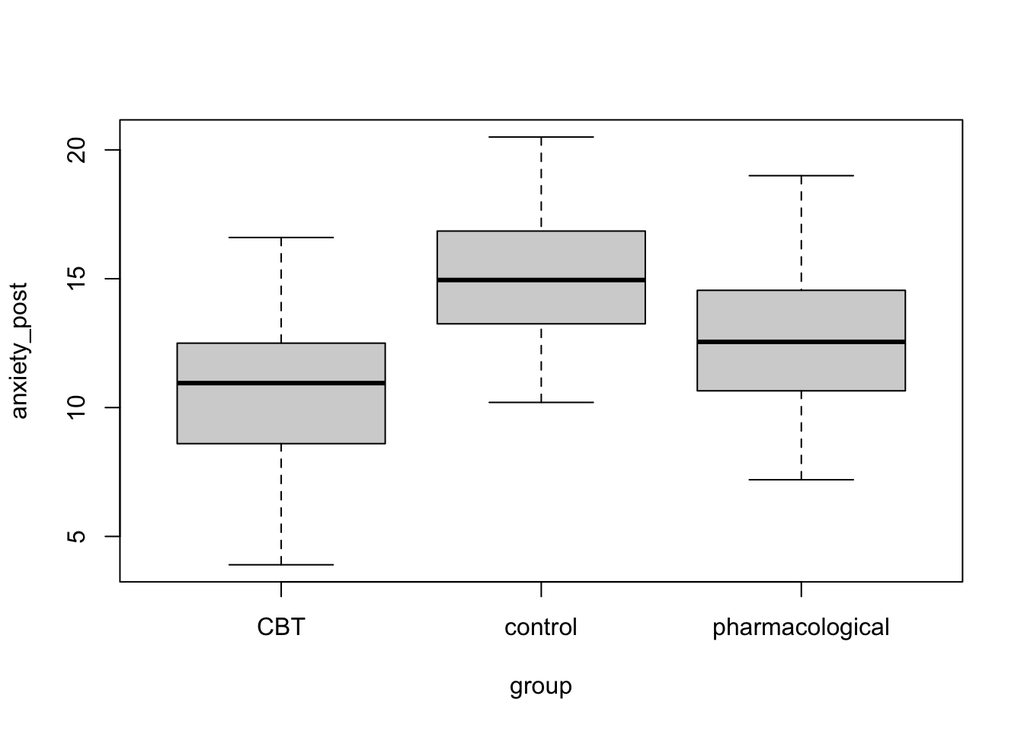

```r
# el grafico del dia 3
boxplot(anxiety_post ~ group,
        data = data_trial)
```

- Una línea: perfecto para **explorar**
- Pero para un informe o un artículo queremos: etiquetas legibles, los datos de cada paciente, colores, un tema limpio…
- Cada uno de esos cambios es una **capa** en `ggplot2`: vamos a construir ese mismo gráfico paso a paso

# Construir un gráfico paso a paso

## El comando básico

```r
ggplot(data = data_trial)
```

- Piensa en un “lienzo vacío”
- Se indican los datos, PERO…
- No se ha indicado **qué** variables usar, ni **cómo** visualizarlas
- Empezarás a pintar en **capas**

## Paso 1: el lienzo vacío con las variables a usar

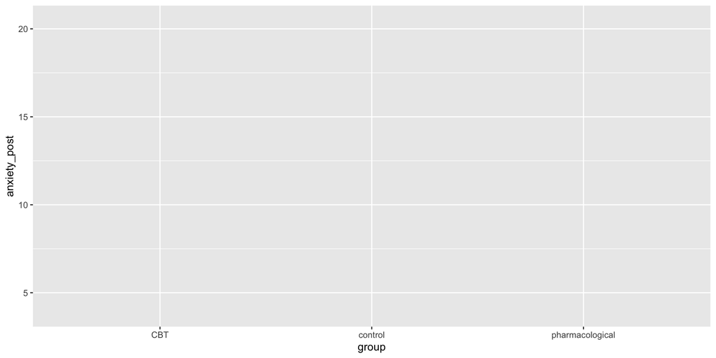

```r
ggplot(data = data_trial,
       mapping = aes(x = group,
                     y = anxiety_post))
```

- En el argumento `mapping`, se indican las estéticas `aes()`, que corresponden a las variables a usar
- Los argumentos `x` y `y` indican qué variables y en qué ejes: los mismos que en la fórmula `anxiety_post ~ group`
- Falta indicar **cómo** queremos visualizarla

## Paso 2: añadir geometría — boxplot

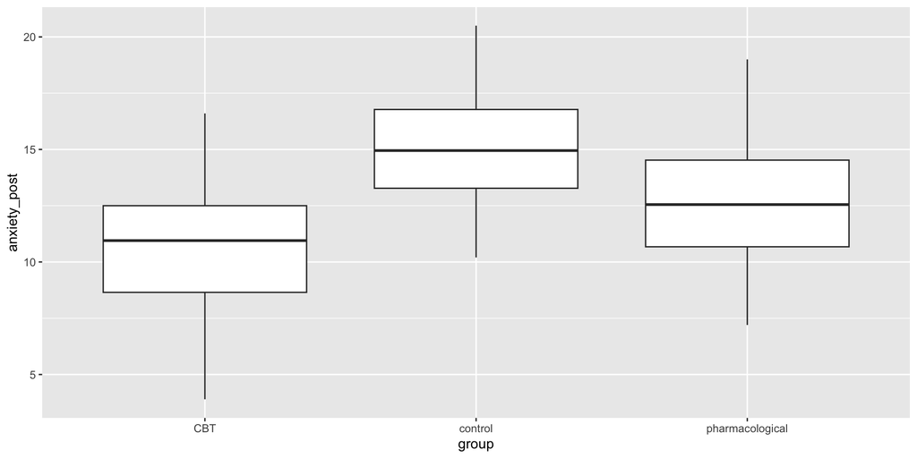

```r
ggplot(data = data_trial,
       mapping = aes(x = group,
                     y = anxiety_post)) +
  geom_boxplot()
```

- Un `geom_*` es el objeto geométrico que utiliza un gráfico para representar los datos
- Los diferentes `geoms` se acceden mediante funciones que empiezan por `geom_`
  - [ggplot2](https://ggplot2.tidyverse.org/reference/index.html) o la “Chuleta” [CheatSheet](https://rstudio.github.io/cheatsheets/data-visualization.pdf)
  - Los que veremos hoy: `geom_boxplot()`, `geom_jitter()`, `geom_point()`, `geom_smooth()`, `geom_histogram()`, `geom_violin()`, `geom_col()`
- Ya tenemos el `boxplot()` de R base; ahora, las capas

## Paso 3a: mapear el color a una variable

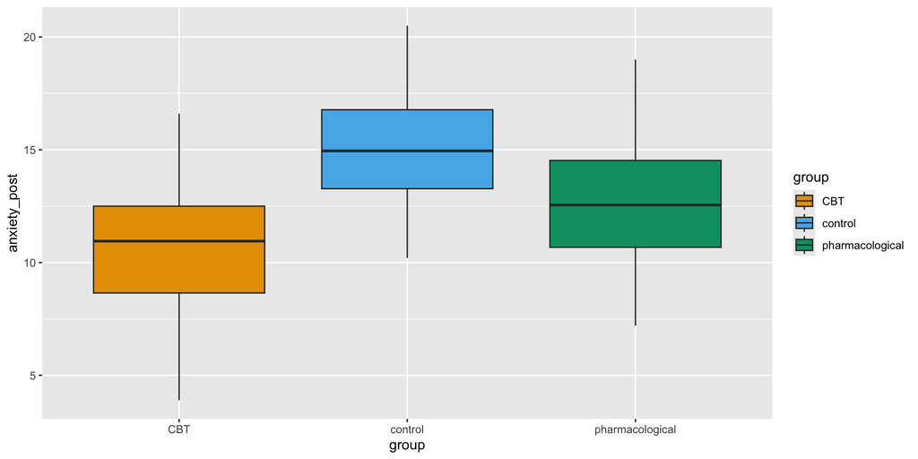

```r
ggplot(data = data_trial,
       mapping = aes(x = group,
                     y = anxiety_post,
                     fill = group)) +
  geom_boxplot()
```

- `fill` = color de **relleno**; `color` = color del **contorno** (líneas y puntos)
- Los `geoms` heredan las estéticas de `ggplot()`: si el grupo va en la raíz, todas las capas se agrupan
- La leyenda aparece sola

## Paso 3b: añadir los datos — `geom_jitter()`

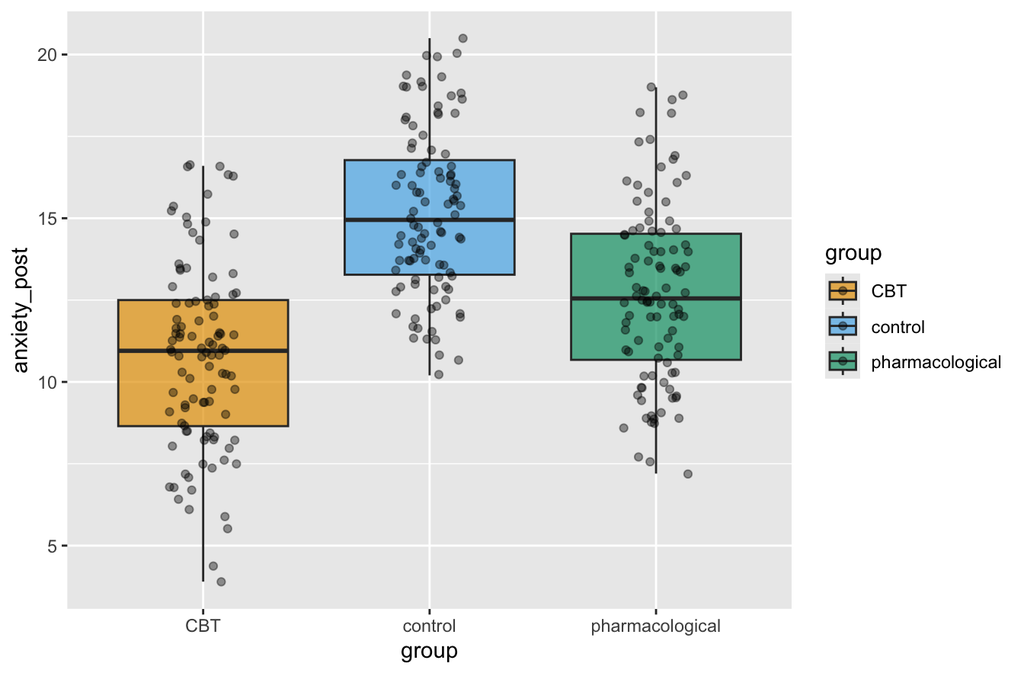

```r
ggplot(data = data_trial,
       mapping = aes(x = group,
                     y = anxiety_post,
                     fill = group)) +
  geom_boxplot(alpha = 0.7,
               outliers = FALSE) +
  geom_jitter(width = 0.15, alpha = 0.4)
```

- Una capa más: cada paciente es un punto; `width` lo desplaza un poco en horizontal para que no se solapen
- `alpha` = transparencia (0-1)
- `outliers = FALSE` en el boxplot: los puntos extremos ya están en `geom_jitter()`, no los dibujamos dos veces

## Paso 3c: estéticas propias de cada capa

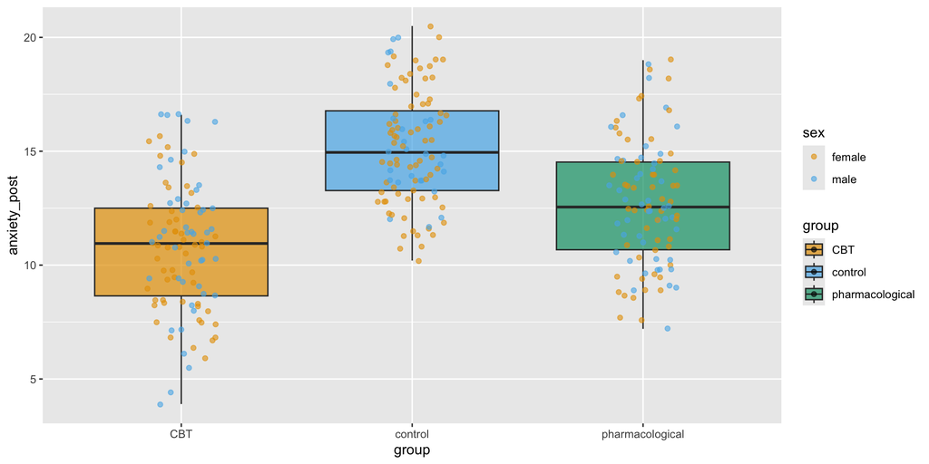

```r
ggplot(data = data_trial,
       mapping = aes(x = group,
                     y = anxiety_post,
                     fill = group)) +
  geom_boxplot(alpha = 0.7,
               outliers = FALSE) +
  geom_jitter(aes(color = sex),
              width = 0.15, alpha = 0.6)
```

- Cada `geom` puede tener su propio `aes()`: aquí los puntos se colorean por `sex` y las cajas siguen rellenas por `group`
- Dentro de `aes()`, el color **depende de los datos**: cada paciente toma el color de su sexo
- Fuera de `aes()`, el valor es **igual para todos** los puntos: `alpha = 0.6` es una transparencia fija. Lo mismo pasaría con `color = "red"` fuera de `aes()`: todos los puntos rojos

## Paso 4: Extra: añadir etiquetas

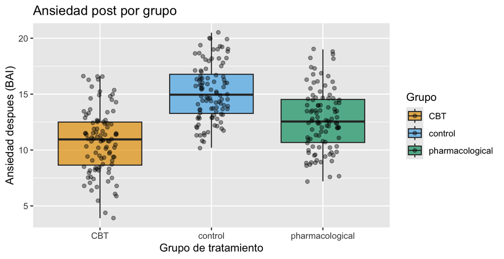

```r
# guardamos el grafico en un objeto
# para seguir anadiendole capas
grafico_ansiedad <- ggplot(data = data_trial,
       mapping = aes(x = group,
                     y = anxiety_post,
                     fill = group)) +
  geom_boxplot(alpha = 0.7,
               outliers = FALSE) +
  geom_jitter(width = 0.15, alpha = 0.4) +
  labs(x     = "Grupo de tratamiento",
       y     = "Ansiedad despues (BAI)",
       title = "Ansiedad post por grupo",
       fill  = "Grupo")
grafico_ansiedad
```

- Se van agregando capas: `labs()`
- ¿Qué argumentos tiene `labs()`? (revisar `?labs`)
- Un gráfico es un **objeto** como cualquier otro resultado: lo guardamos con `<-` y a partir de ahora solo le **sumamos capas**

## Paso 5: Extra: añadir `themes` (formatos generales)

```r
grafico_ansiedad +
  theme_classic()
```

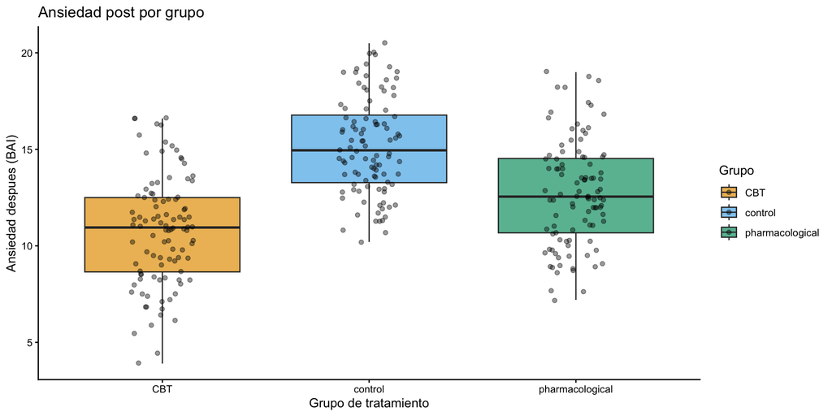

- Pueden crear sus propios `themes()`
- Pero, ya hay algunos themes prestablecidos

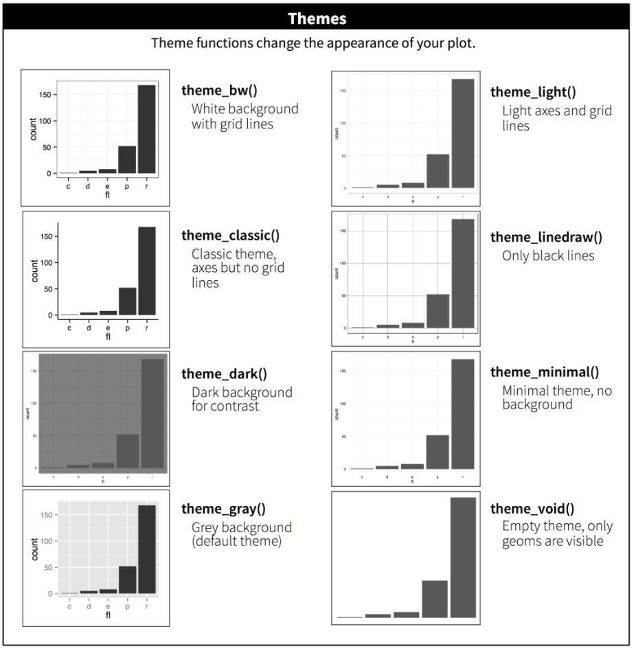

## Paso 5 (extra): `theme_apa()` — formato de publicación

```r
# install.packages("jtools")
library(jtools)

grafico_ansiedad +
  theme_apa() +
  # el eje x ya dice el grupo
  theme(legend.position = "none")
```

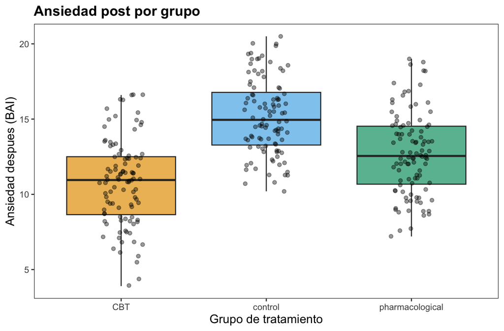

- `jtools::theme_apa()`: fondo blanco, sin rejilla, tipografía sobria: el formato que piden las revistas de psicología
- Se añade como cualquier otro `theme_*()`; `theme()` después ajusta detalles (aquí, quitar la leyenda redundante)